# Sample Report

author

January 19, 2016

```r
require(edaR)

str(edaR_test)
```

```
## 'data.frame':    50 obs. of  17 variables:
##  $ state.name    : chr  "Alabama" NA "Arizona" NA ...
##  $ state.abb     : chr  "AL" "AK" "AZ" "AR" ...
##  $ state.area    : num  51609 589757 113909 53104 158693 ...
##  $ x             : num  -86.8 -127.2 -111.6 -92.3 -119.8 ...
##  $ y             : num  32.6 49.2 34.2 NA 36.5 ...
##  $ state.division: Factor w/ 9 levels "New England",..: 4 9 8 5 NA 8 1 3 3 3 ...
##  $ state.region  : Factor w/ 4 levels "Northeast","South",..: 2 4 4 2 4 4 1 2 2 2 ...
##  $ Population    : num  3615 365 2212 2110 21198 ...
##  $ Income        : num  3624 6315 4530 3378 5114 ...
##  $ Illiteracy    : num  2.1 1.5 1.8 1.9 1.1 0.7 1.1 0.9 1.3 2 ...
##  $ Life.Exp      : num  69 69.3 70.5 70.7 71.7 ...
##  $ Murder        : num  15.1 11.3 7.8 10.1 10.3 6.8 NA 6.2 10.7 13.9 ...
##  $ HS.Grad       : num  41.3 66.7 58.1 39.9 62.6 63.9 NA 54.6 52.6 40.6 ...
##  $ Frost         : num  20 NA 15 65 NA 166 NA 103 11 60 ...
##  $ Area          : num  50708 566432 113417 51945 156361 ...
##  $ rand_dates    : Date, format: "2001-10-22" "2009-12-11" ...
##  $ rand_bool     : logi  TRUE TRUE FALSE FALSE TRUE FALSE ...
```

# Now for the actual package:

```r
  raw_lists <- singleVarStats(edaR_test)

  printSingleVarStats(raw_lists)
```

## Single Var Interactions

### state.name

- **length**: *50*
- **naCnt**: *6*
- **naPerc**: *0.12*
- **unique_length**: *45*
- **uniquePerc**: *0.9*

|  | ct | prop |
| --- | --- | --- |
| **Alabama** | 1 | 0.02 |
| **Arizona** | 1 | 0.02 |
| **California** | 1 | 0.02 |
| **Colorado** | 1 | 0.02 |
| **Connecticut** | 1 | 0.02 |
| **Delaware** | 1 | 0.02 |
| **Florida** | 1 | 0.02 |
| **Georgia** | 1 | 0.02 |
| **Hawaii** | 1 | 0.02 |
| **Idaho** | 1 | 0.02 |

- **nchar_fn**:

  | min | low-hindge | median | up-hindge | max |
  | --- | --- | --- | --- | --- |
  | 2 | 6 | 8 | 10 | 14 |

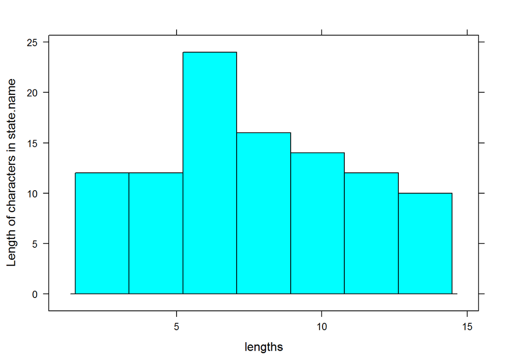

### state.abb

- **length**: *50*
- **naCnt**: *3*
- **naPerc**: *0.06*
- **unique_length**: *48*
- **uniquePerc**: *0.96*

|  | ct | prop |
| --- | --- | --- |
| **AK** | 1 | 0.02 |
| **AL** | 1 | 0.02 |
| **AR** | 1 | 0.02 |
| **AZ** | 1 | 0.02 |
| **CA** | 1 | 0.02 |
| **CO** | 1 | 0.02 |
| **CT** | 1 | 0.02 |
| **DE** | 1 | 0.02 |
| **FL** | 1 | 0.02 |
| **GA** | 1 | 0.02 |

- **nchar_fn**:

  | min | low-hindge | median | up-hindge | max |
  | --- | --- | --- | --- | --- |
  | 2 | 2 | 2 | 2 | 2 |

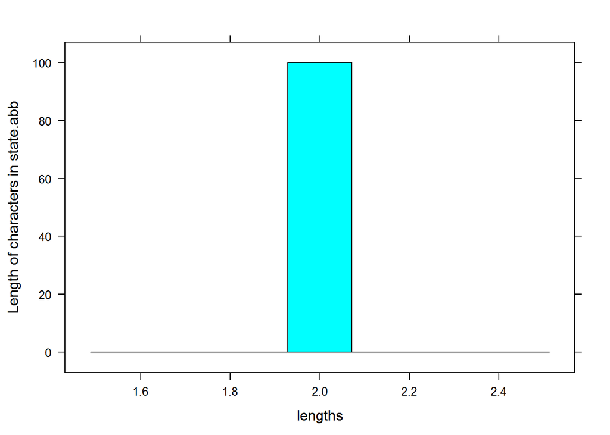

### state.area

- **length**: *50*
- **naCnt**: *3*
- **naPerc**: *0.06*
- **unique_length**: *48*
- **uniquePerc**: *0.96*

|  | ct | prop |
| --- | --- | --- |
| **1214** | 1 | 0.02 |
| **2057** | 1 | 0.02 |
| **6450** | 1 | 0.02 |
| **7836** | 1 | 0.02 |
| **8257** | 1 | 0.02 |
| **9304** | 1 | 0.02 |
| **9609** | 1 | 0.02 |
| **10577** | 1 | 0.02 |
| **24181** | 1 | 0.02 |
| **31055** | 1 | 0.02 |

- **fivenum**:

  | min | low-hindge | median | up-hindge | max |
  | --- | --- | --- | --- | --- |
  | 1214 | 38343 | 56154 | 80392 | 589757 |

- **keystats**:

  | mean | sd | skewness | kurtosis |
  | --- | --- | --- | --- |
  | 73324 | 90532 | 4.113 | 20.06 |

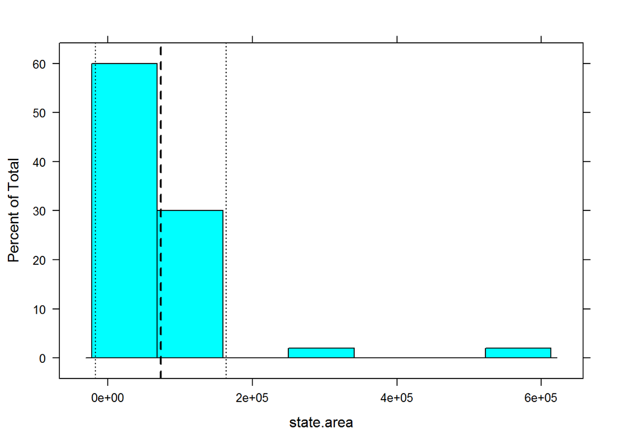

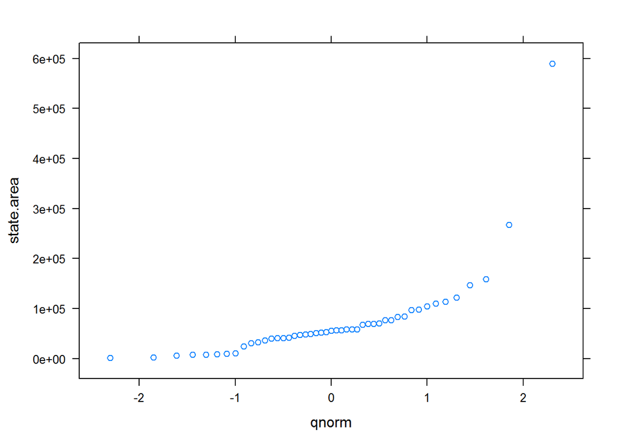

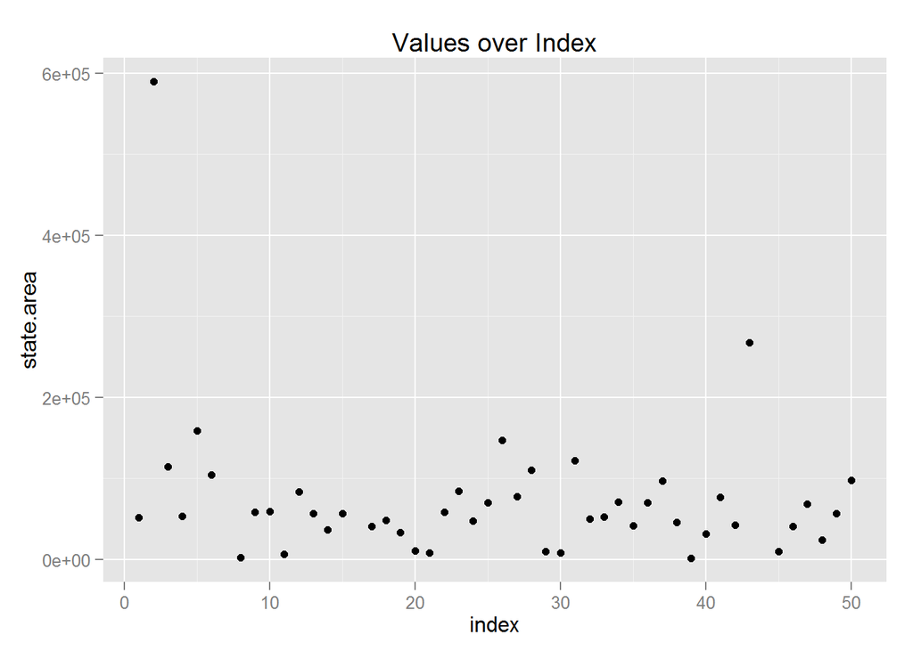

### x

- **length**: *50*
- **naCnt**: *4*
- **naPerc**: *0.08*
- **unique_length**: *47*
- **uniquePerc**: *0.94*

|  | ct | prop |
| --- | --- | --- |
| **-127.25** | 1 | 0.02 |
| **-126.25** | 1 | 0.02 |
| **-120.068** | 1 | 0.02 |
| **-119.773** | 1 | 0.02 |
| **-119.746** | 1 | 0.02 |
| **-116.851** | 1 | 0.02 |
| **-113.93** | 1 | 0.02 |
| **-111.625** | 1 | 0.02 |
| **-111.33** | 1 | 0.02 |
| **-105.942** | 1 | 0.02 |

- **fivenum**:

  | min | low-hindge | median | up-hindge | max |
  | --- | --- | --- | --- | --- |
  | -127.2 | -100.1 | -89.9 | -78.2 | -68.98 |

- **keystats**:

  | mean | sd | skewness | kurtosis |
  | --- | --- | --- | --- |
  | -92.2 | 16.41 | -0.5106 | -0.8351 |

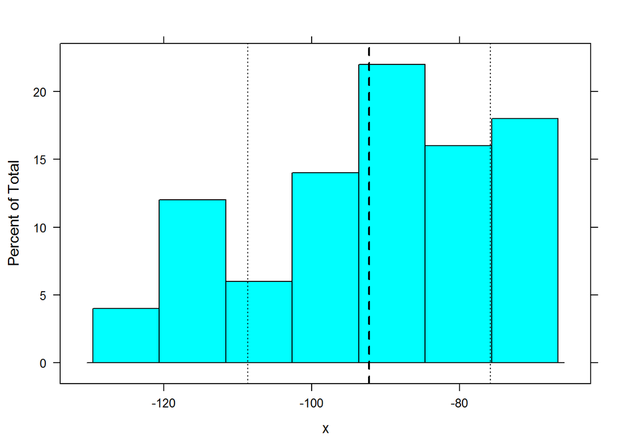

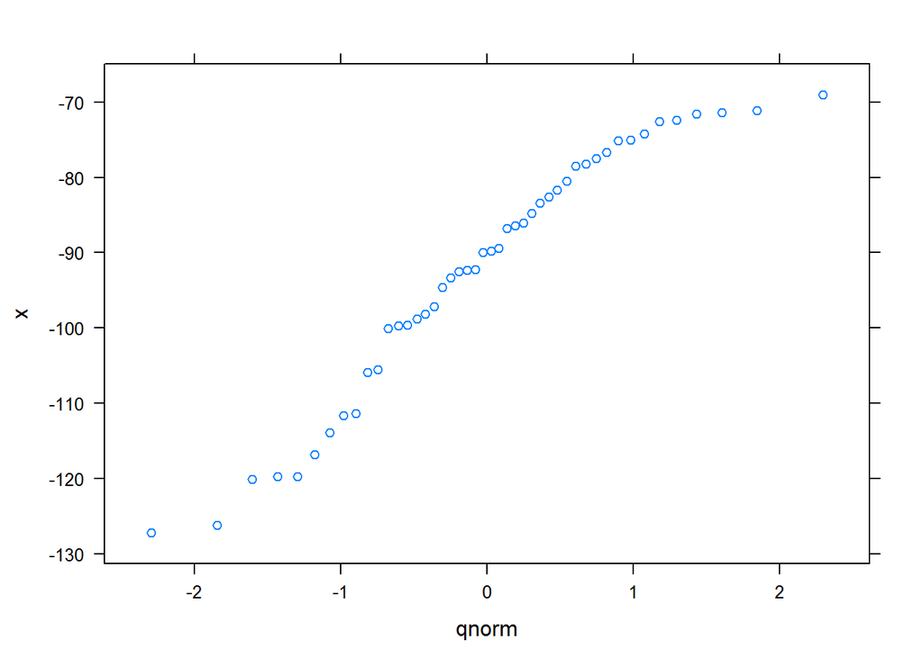

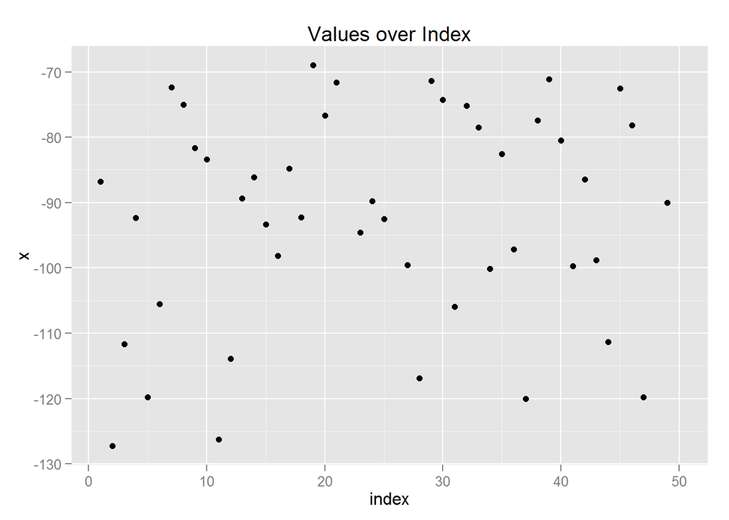

### y

- **length**: *50*
- **naCnt**: *6*
- **naPerc**: *0.12*
- **unique_length**: *41*
- **uniquePerc**: *0.82*

|  | ct | prop |
| --- | --- | --- |
| **38.4204** | 2 | 0.04 |
| **39.1063** | 2 | 0.04 |
| **41.5928** | 2 | 0.04 |
| **43.1361** | 2 | 0.04 |
| **27.8744** | 1 | 0.02 |
| **30.6181** | 1 | 0.02 |
| **31.3897** | 1 | 0.02 |
| **31.75** | 1 | 0.02 |
| **32.3329** | 1 | 0.02 |
| **32.5901** | 1 | 0.02 |

- **fivenum**:

  | min | low-hindge | median | up-hindge | max |
  | --- | --- | --- | --- | --- |
  | 27.87 | 35.59 | 39.66 | 43.26 | 49.25 |

- **keystats**:

  | mean | sd | skewness | kurtosis |
  | --- | --- | --- | --- |
  | 39.51 | 5.152 | -0.2324 | -0.7984 |

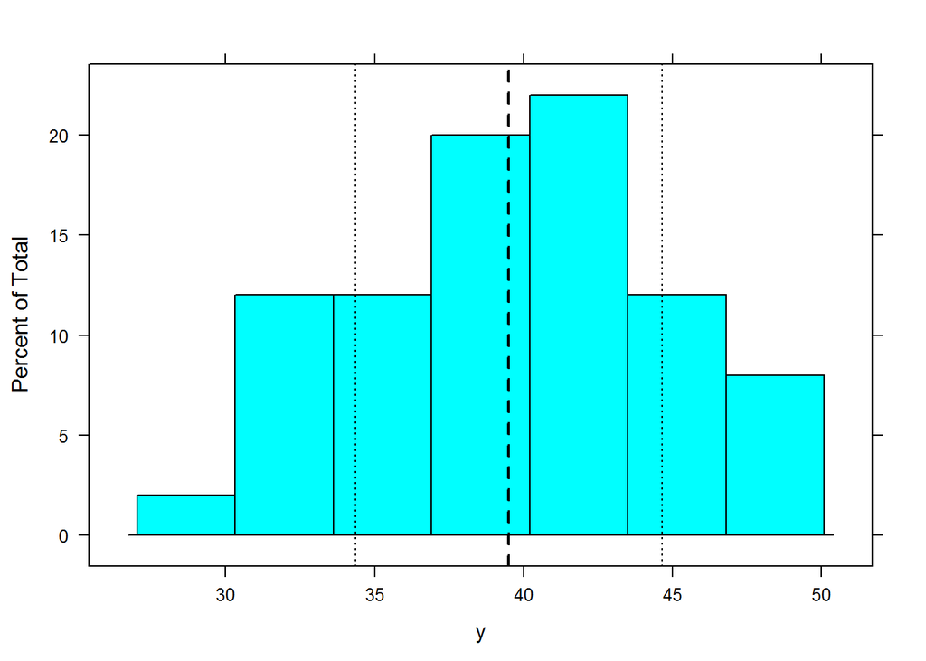

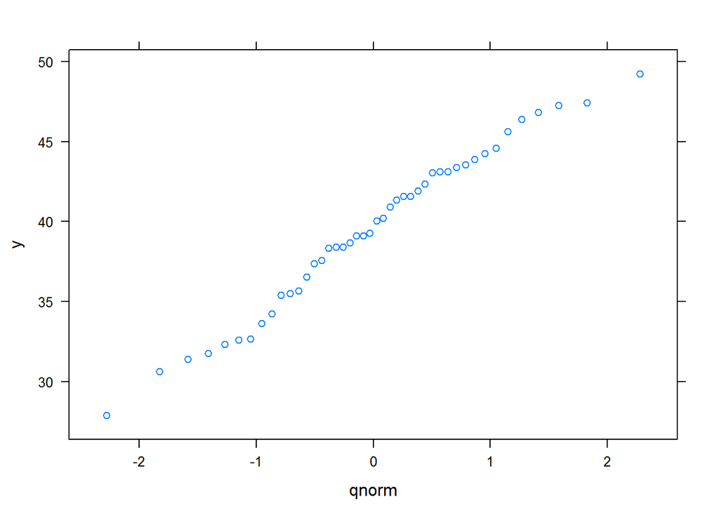

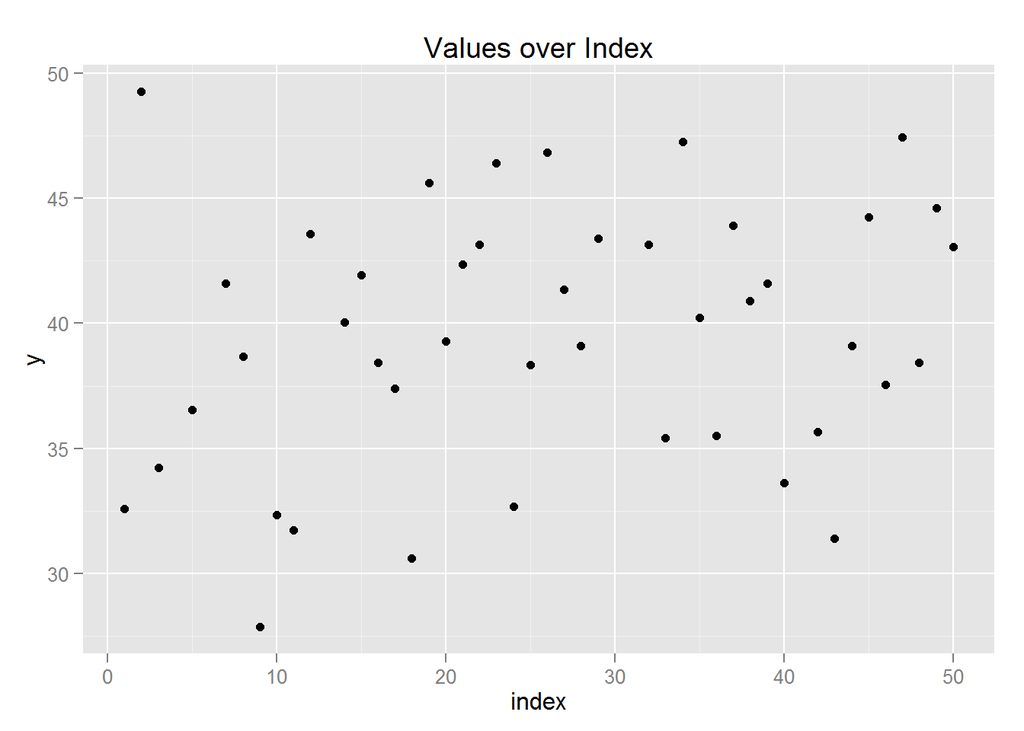

### state.division

- **length**: *50*
- **naCnt**: *6*
- **naPerc**: *0.12*
- **unique_length**: *10*
- **uniquePerc**: *0.2*

|  | ct | prop |
| --- | --- | --- |
| **Mountain** | 8 | 0.16 |
| **South Atlantic** | 7 | 0.14 |
| **West North Central** | 7 | 0.14 |
| **New England** | 6 | 0.12 |
| **West South Central** | 4 | 0.08 |
| **East North Central** | 4 | 0.08 |
| **East South Central** | 3 | 0.06 |
| **Pacific** | 3 | 0.06 |
| **Middle Atlantic** | 2 | 0.04 |

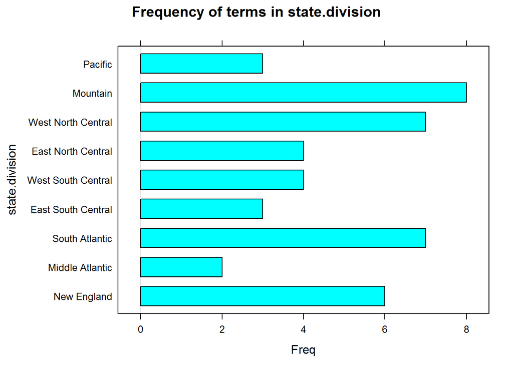

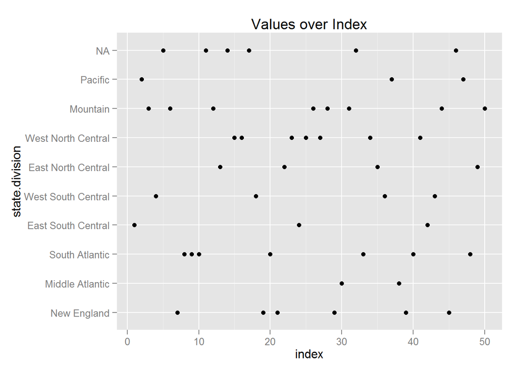

### state.region

- **length**: *50*
- **naCnt**: *1*
- **naPerc**: *0.02*
- **unique_length**: *5*
- **uniquePerc**: *0.1*

|  | ct | prop |
| --- | --- | --- |
| **South** | 16 | 0.32 |
| **North Central** | 12 | 0.24 |
| **West** | 12 | 0.24 |
| **Northeast** | 9 | 0.18 |

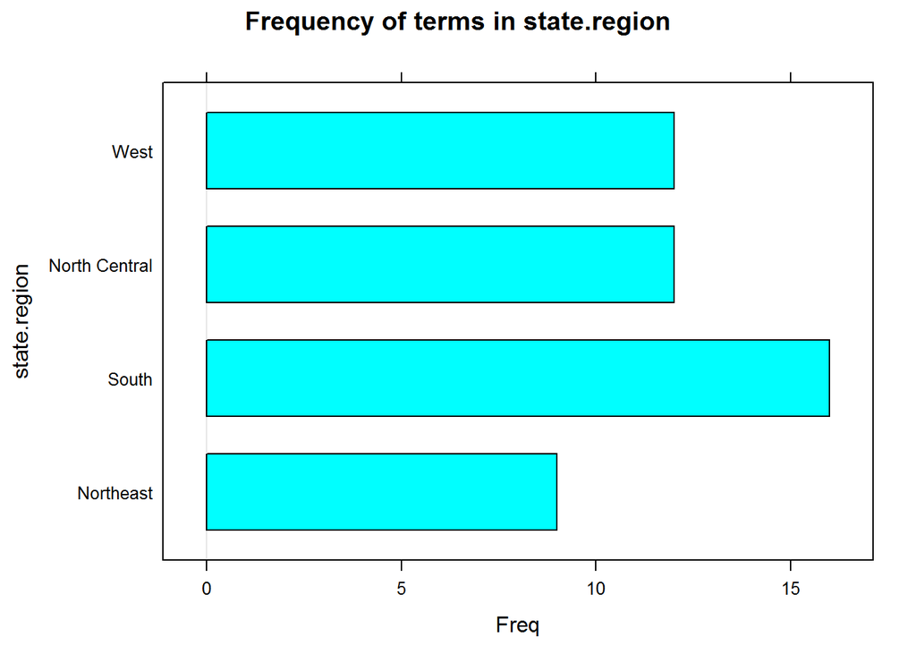

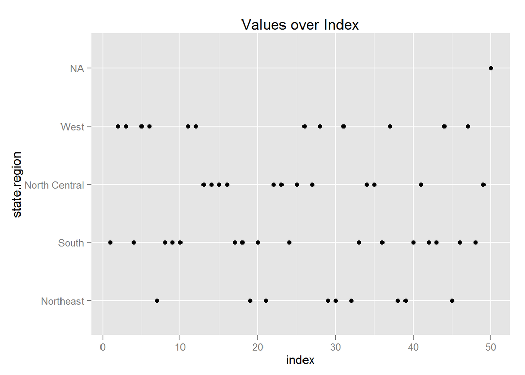

### Population

- **length**: *50*
- **naCnt**: *2*
- **naPerc**: *0.04*
- **unique_length**: *49*
- **uniquePerc**: *0.98*

|  | ct | prop |
| --- | --- | --- |
| **365** | 1 | 0.02 |
| **472** | 1 | 0.02 |
| **579** | 1 | 0.02 |
| **590** | 1 | 0.02 |
| **637** | 1 | 0.02 |
| **681** | 1 | 0.02 |
| **746** | 1 | 0.02 |
| **812** | 1 | 0.02 |
| **813** | 1 | 0.02 |
| **868** | 1 | 0.02 |

- **fivenum**:

  | min | low-hindge | median | up-hindge | max |
  | --- | --- | --- | --- | --- |
  | 365 | 1101 | 2980 | 5147 | 21198 |

- **keystats**:

  | mean | sd | skewness | kurtosis |
  | --- | --- | --- | --- |
  | 4367 | 4513 | 1.875 | 3.519 |

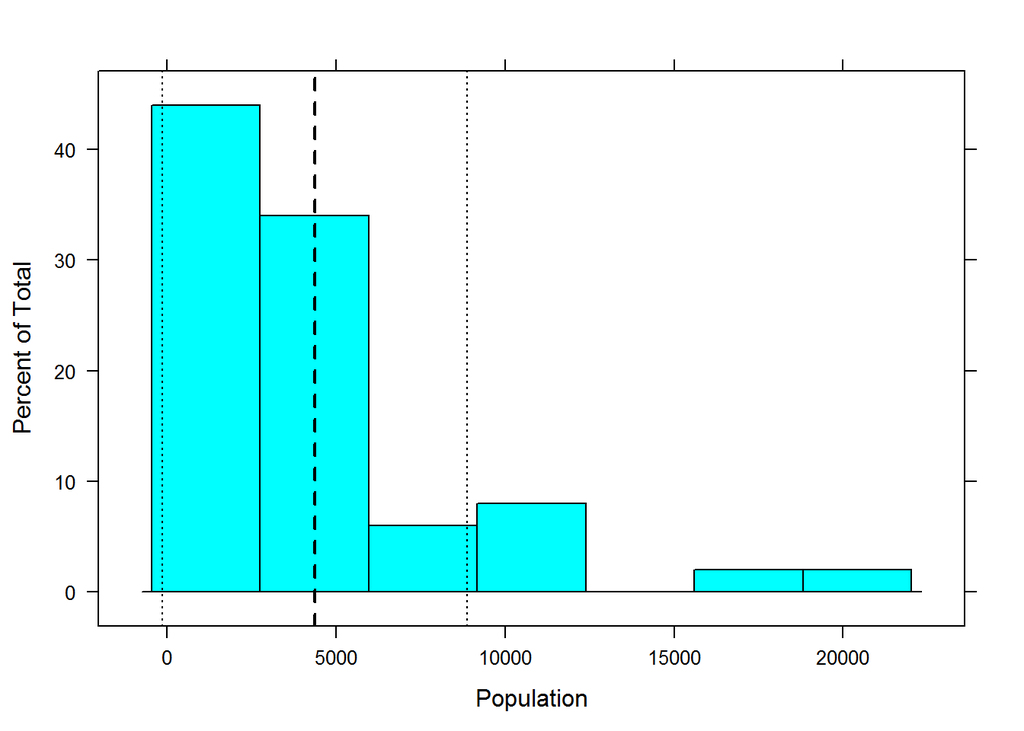

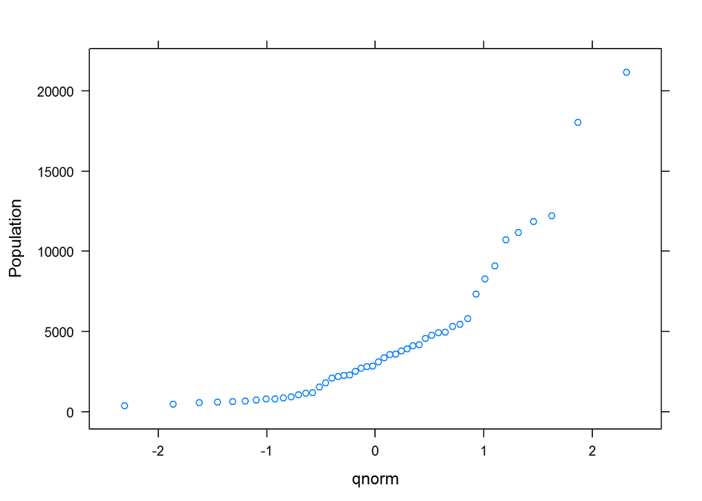

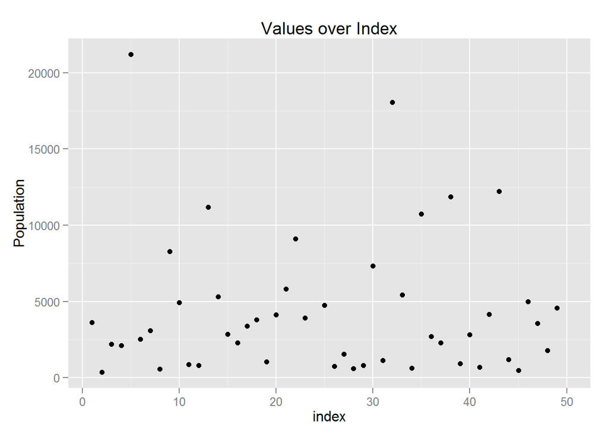

### Income

- **length**: *50*
- **naCnt**: *7*
- **naPerc**: *0.14*
- **unique_length**: *44*
- **uniquePerc**: *0.88*

|  | ct | prop |
| --- | --- | --- |
| **3098** | 1 | 0.02 |
| **3378** | 1 | 0.02 |
| **3601** | 1 | 0.02 |
| **3624** | 1 | 0.02 |
| **3694** | 1 | 0.02 |
| **3712** | 1 | 0.02 |
| **3821** | 1 | 0.02 |
| **3875** | 1 | 0.02 |
| **3907** | 1 | 0.02 |
| **3983** | 1 | 0.02 |

- **fivenum**:

  | min | low-hindge | median | up-hindge | max |
  | --- | --- | --- | --- | --- |
  | 3098 | 4056 | 4561 | 4874 | 6315 |

- **keystats**:

  | mean | sd | skewness | kurtosis |
  | --- | --- | --- | --- |
  | 4499 | 617.7 | 0.1076 | 0.3498 |

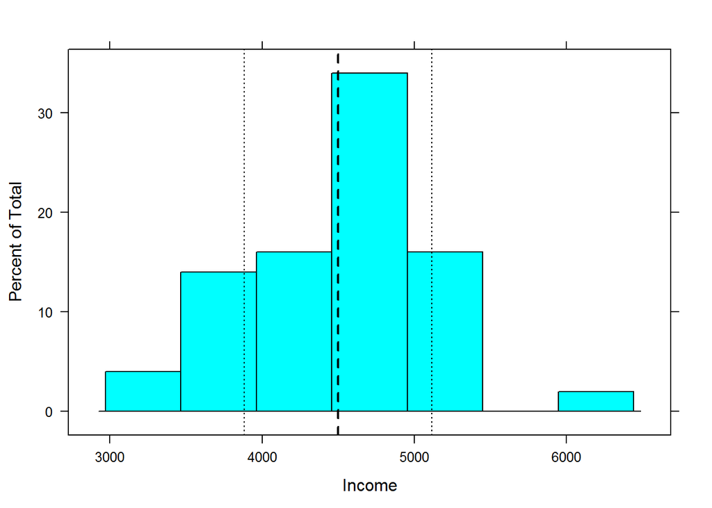

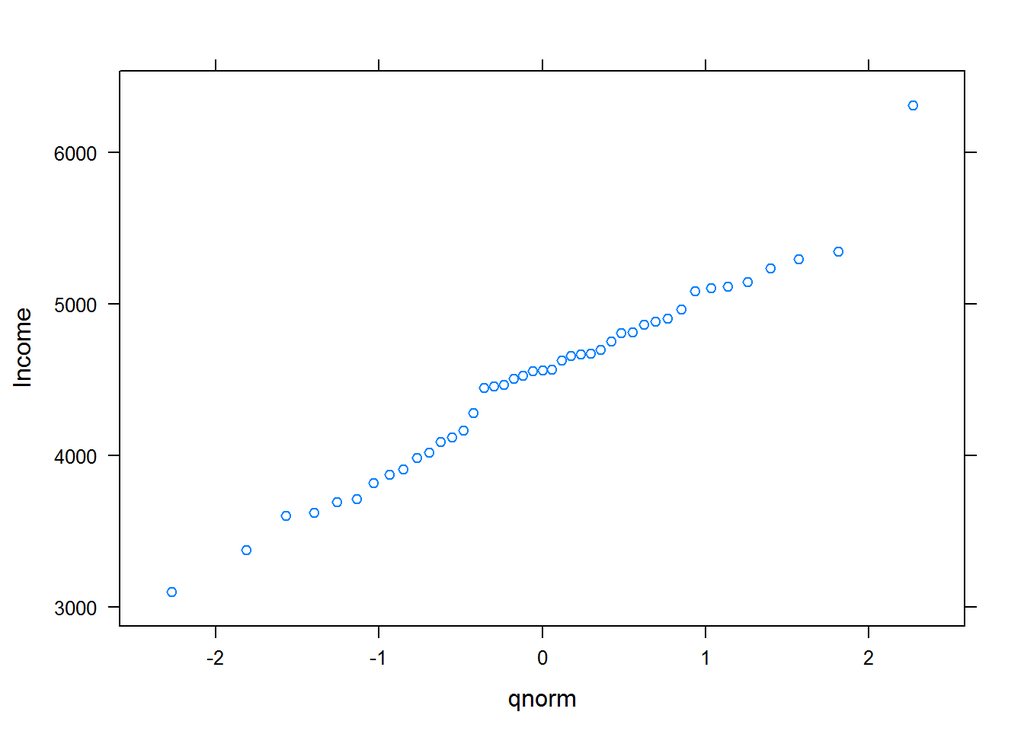

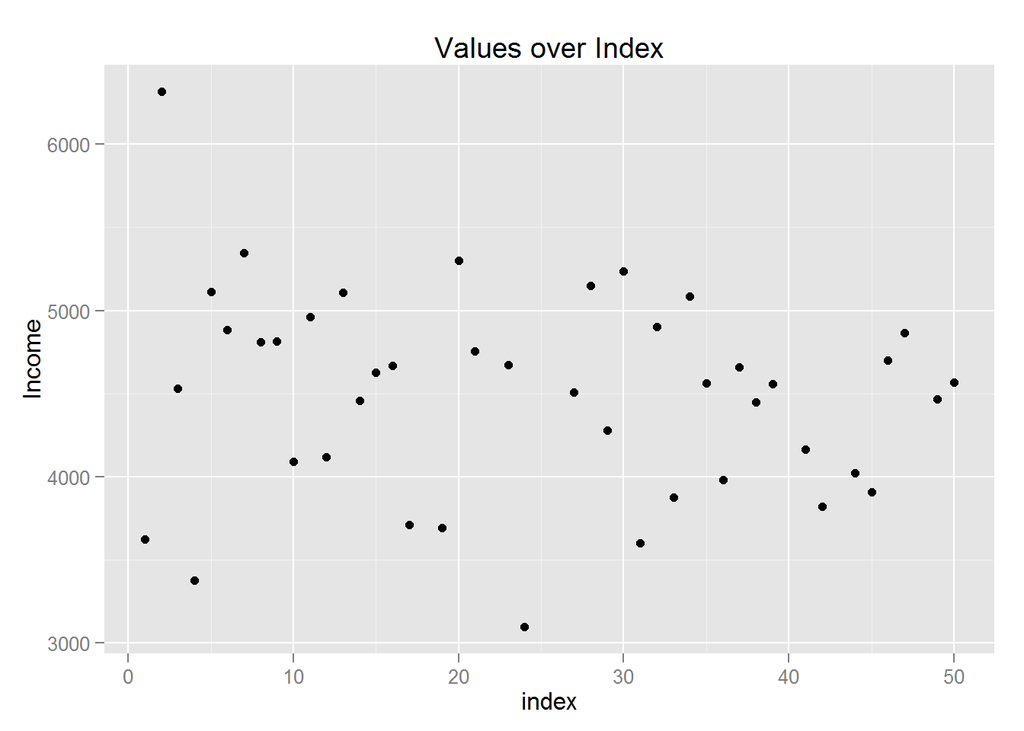

### Illiteracy

- **length**: *50*
- **naCnt**: *6*
- **naPerc**: *0.12*
- **unique_length**: *20*
- **uniquePerc**: *0.4*

|  | ct | prop |
| --- | --- | --- |
| **0.6** | 9 | 0.18 |
| **1.1** | 5 | 0.1 |
| **0.7** | 4 | 0.08 |
| **0.8** | 3 | 0.06 |
| **0.9** | 3 | 0.06 |
| **0.5** | 2 | 0.04 |
| **1.3** | 2 | 0.04 |
| **1.4** | 2 | 0.04 |
| **1.8** | 2 | 0.04 |
| **1.9** | 2 | 0.04 |

- **fivenum**:

  | min | low-hindge | median | up-hindge | max |
  | --- | --- | --- | --- | --- |
  | 0.5 | 0.65 | 1.1 | 1.75 | 2.8 |

- **keystats**:

  | mean | sd | skewness | kurtosis |
  | --- | --- | --- | --- |
  | 1.214 | 0.6282 | 0.7008 | -0.7302 |

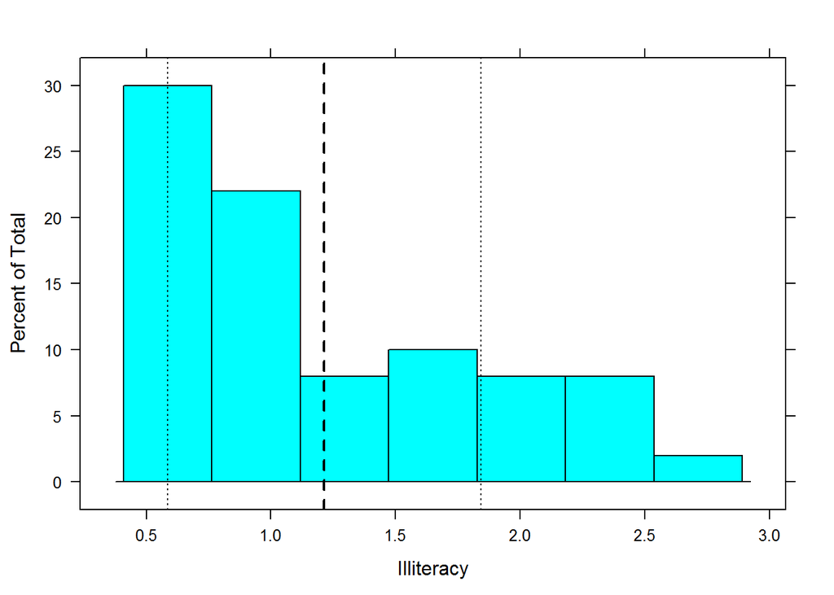

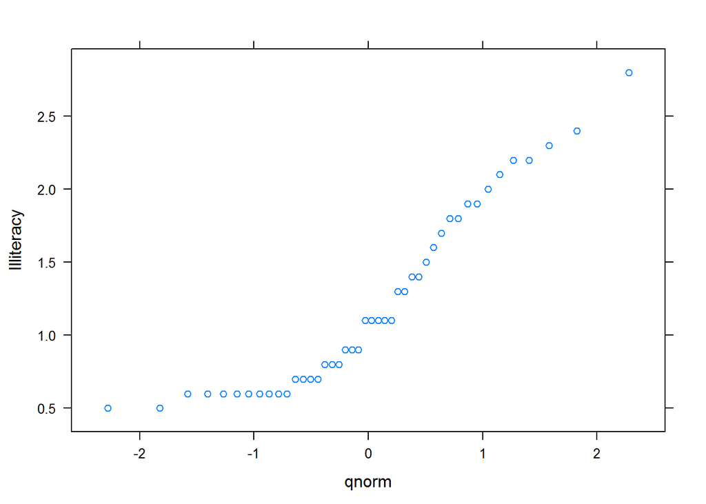

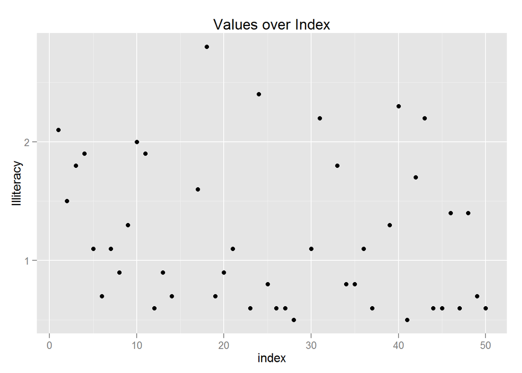

### Life.Exp

- **length**: *50*
- **naCnt**: *6*
- **naPerc**: *0.12*
- **unique_length**: *43*
- **uniquePerc**: *0.86*

|  | ct | prop |
| --- | --- | --- |
| **70.66** | 2 | 0.04 |
| **72.48** | 2 | 0.04 |
| **67.96** | 1 | 0.02 |
| **68.09** | 1 | 0.02 |
| **68.54** | 1 | 0.02 |
| **68.76** | 1 | 0.02 |
| **69.03** | 1 | 0.02 |
| **69.05** | 1 | 0.02 |
| **69.21** | 1 | 0.02 |
| **69.31** | 1 | 0.02 |

- **fivenum**:

  | min | low-hindge | median | up-hindge | max |
  | --- | --- | --- | --- | --- |
  | 67.96 | 70.09 | 70.67 | 71.89 | 72.96 |

- **keystats**:

  | mean | sd | skewness | kurtosis |
  | --- | --- | --- | --- |
  | 70.8 | 1.337 | -0.239 | -0.835 |

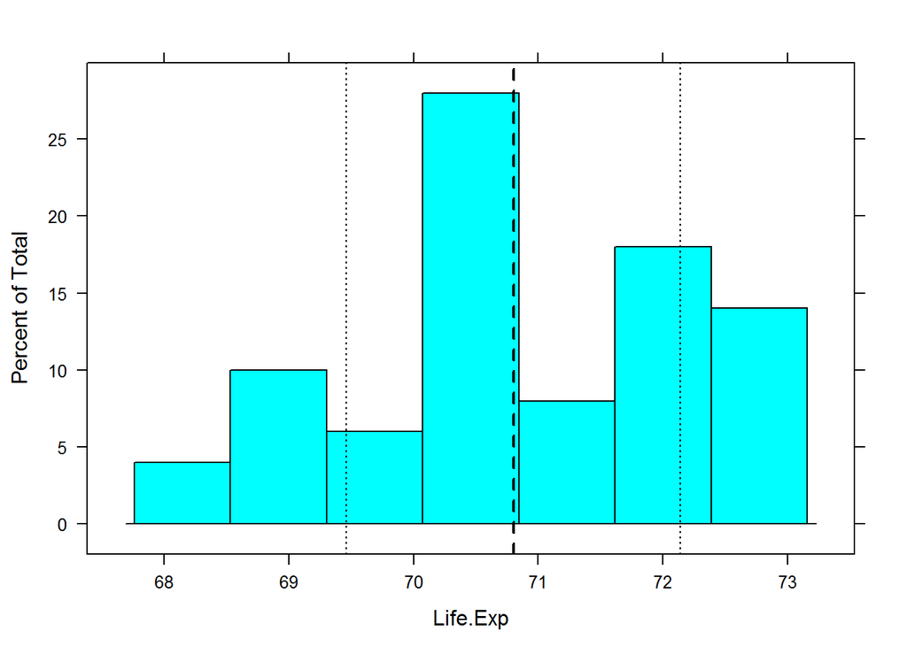

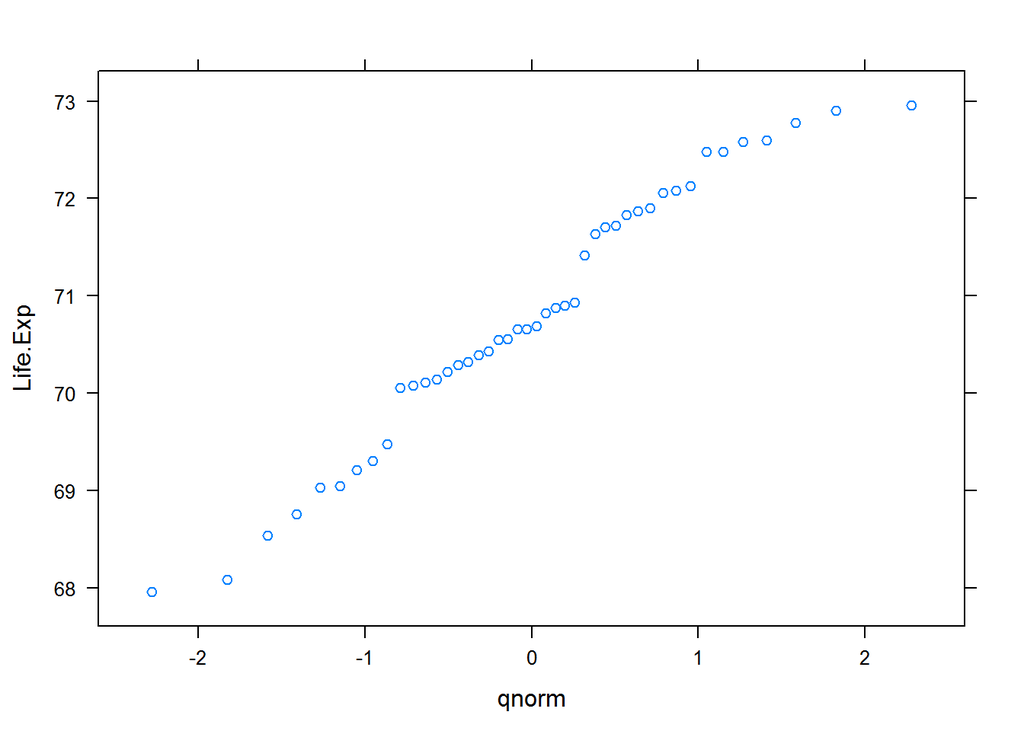

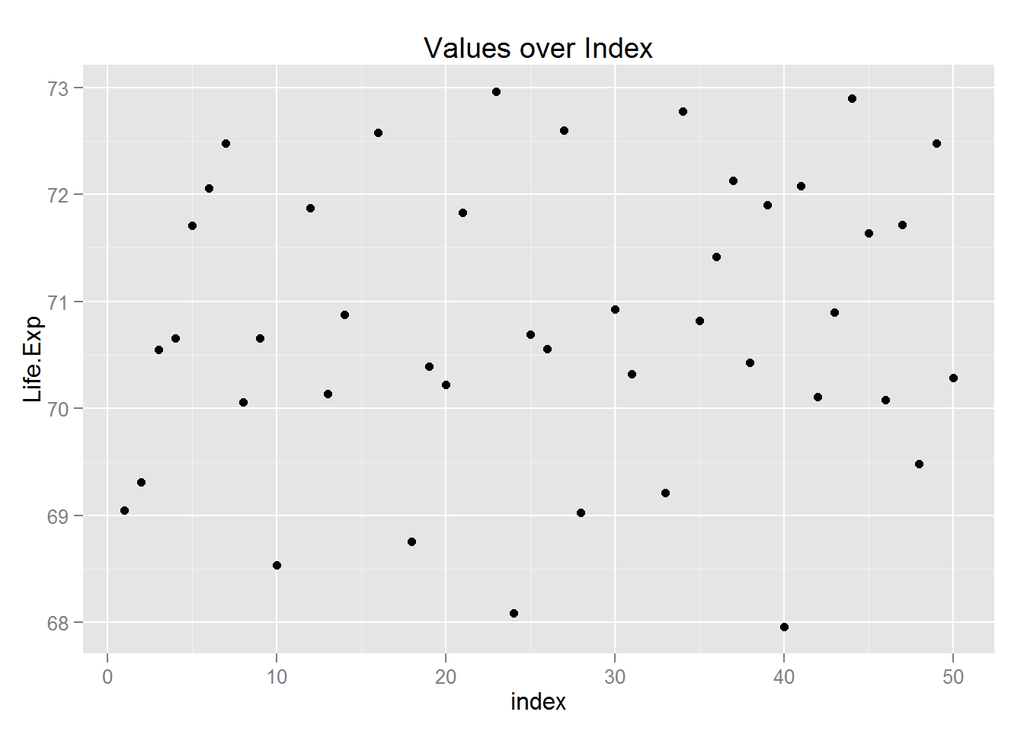

### Murder

- **length**: *50*
- **naCnt**: *3*
- **naPerc**: *0.06*
- **unique_length**: *42*
- **uniquePerc**: *0.84*

|  | ct | prop |
| --- | --- | --- |
| **2.3** | 2 | 0.04 |
| **3.3** | 2 | 0.04 |
| **4.5** | 2 | 0.04 |
| **6.2** | 2 | 0.04 |
| **10.3** | 2 | 0.04 |
| **11.1** | 2 | 0.04 |
| **1.4** | 1 | 0.02 |
| **1.7** | 1 | 0.02 |
| **2.4** | 1 | 0.02 |
| **2.9** | 1 | 0.02 |

- **fivenum**:

  | min | low-hindge | median | up-hindge | max |
  | --- | --- | --- | --- | --- |
  | 1.4 | 4.5 | 6.9 | 10.8 | 15.1 |

- **keystats**:

  | mean | sd | skewness | kurtosis |
  | --- | --- | --- | --- |
  | 7.523 | 3.677 | 0.09624 | -1.189 |

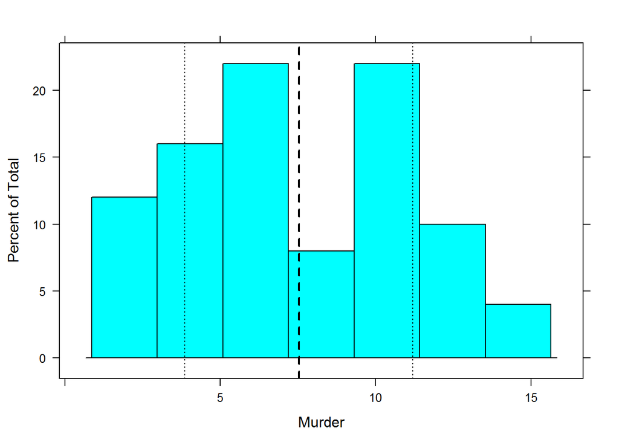

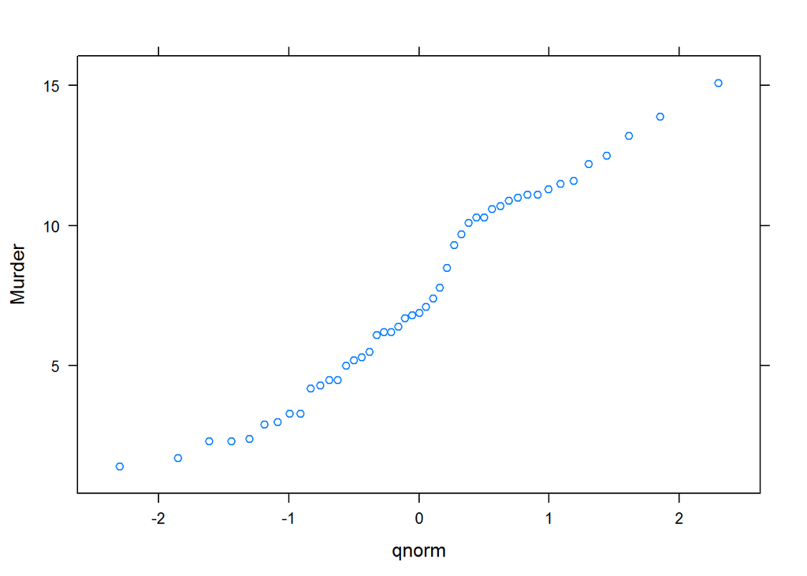

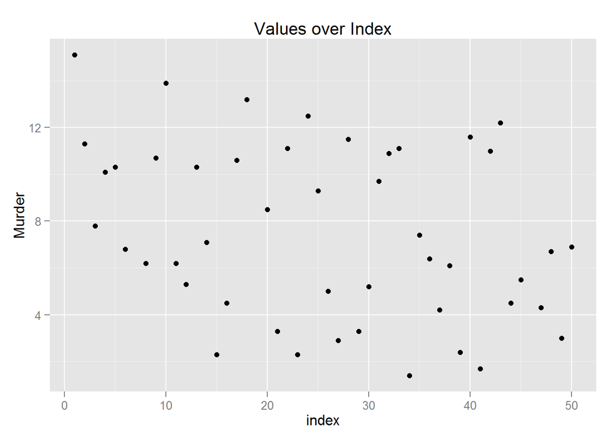

### HS.Grad

- **length**: *50*
- **naCnt**: *6*
- **naPerc**: *0.12*
- **unique_length**: *42*
- **uniquePerc**: *0.84*

|  | ct | prop |
| --- | --- | --- |
| **38.5** | 2 | 0.04 |
| **52.6** | 2 | 0.04 |
| **57.6** | 2 | 0.04 |
| **37.8** | 1 | 0.02 |
| **39.9** | 1 | 0.02 |
| **40.6** | 1 | 0.02 |
| **41** | 1 | 0.02 |
| **41.3** | 1 | 0.02 |
| **41.8** | 1 | 0.02 |
| **46.4** | 1 | 0.02 |

- **fivenum**:

  | min | low-hindge | median | up-hindge | max |
  | --- | --- | --- | --- | --- |
  | 37.8 | 49.05 | 53.9 | 59.25 | 67.3 |

- **keystats**:

  | mean | sd | skewness | kurtosis |
  | --- | --- | --- | --- |
  | 53.57 | 8.155 | -0.4082 | -0.7796 |

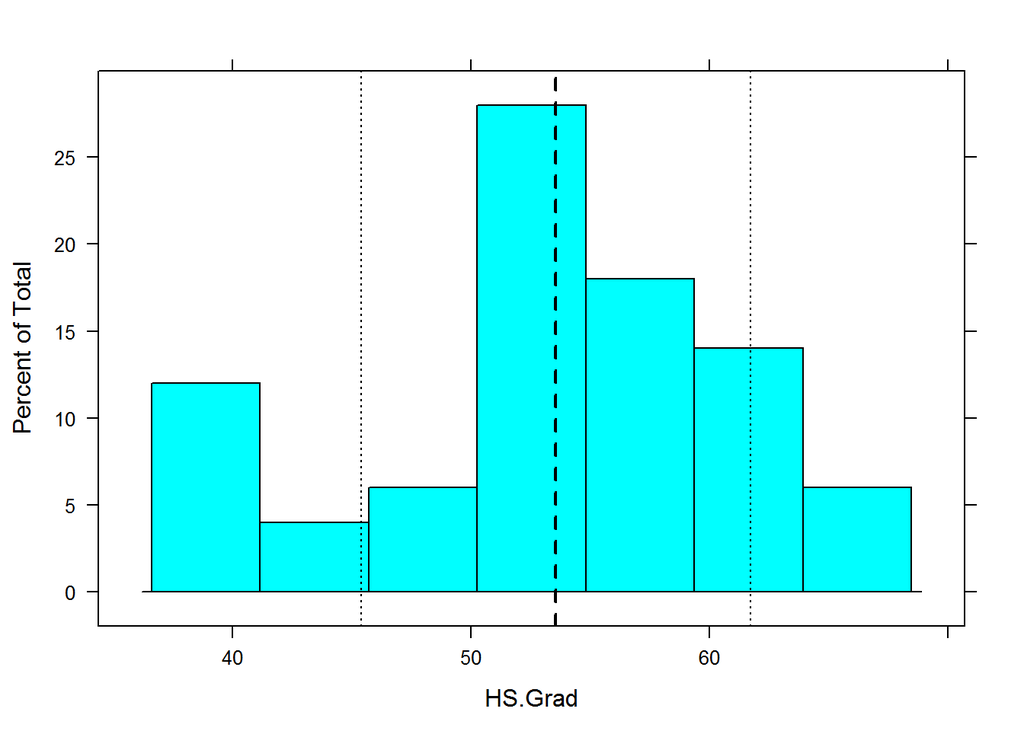

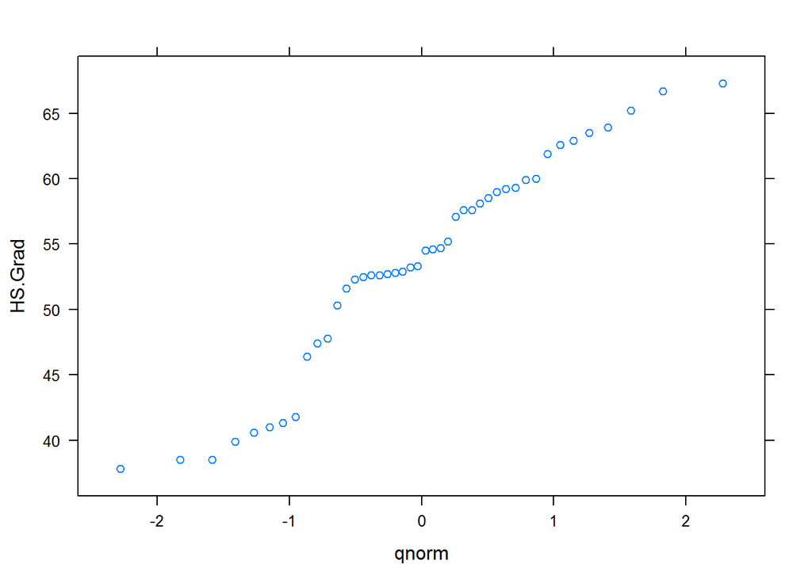

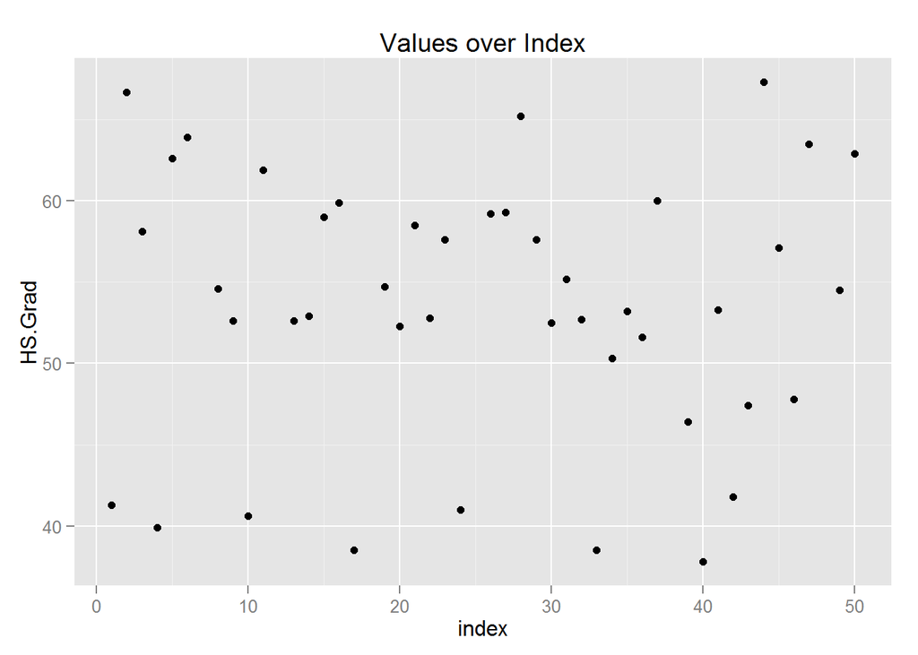

### Frost

- **length**: *50*
- **naCnt**: *7*
- **naPerc**: *0.14*
- **unique_length**: *40*
- **uniquePerc**: *0.8*

|  | ct | prop |
| --- | --- | --- |
| **65** | 2 | 0.04 |
| **103** | 2 | 0.04 |
| **126** | 2 | 0.04 |
| **127** | 2 | 0.04 |
| **0** | 1 | 0.02 |
| **11** | 1 | 0.02 |
| **12** | 1 | 0.02 |
| **15** | 1 | 0.02 |
| **20** | 1 | 0.02 |
| **32** | 1 | 0.02 |

- **fivenum**:

  | min | low-hindge | median | up-hindge | max |
  | --- | --- | --- | --- | --- |
  | 0 | 65 | 114 | 138 | 188 |

- **keystats**:

  | mean | sd | skewness | kurtosis |
  | --- | --- | --- | --- |
  | 102.3 | 51.43 | -0.3507 | -0.9156 |

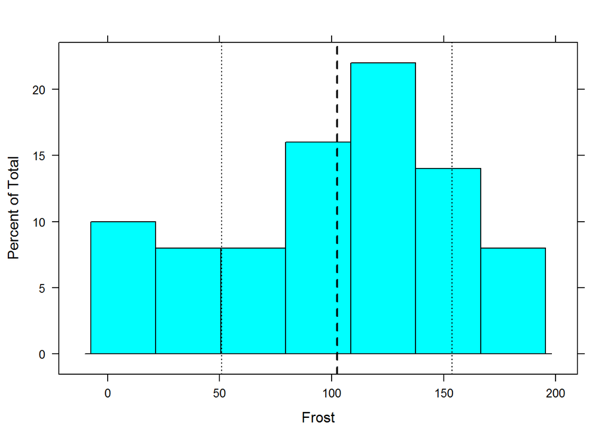

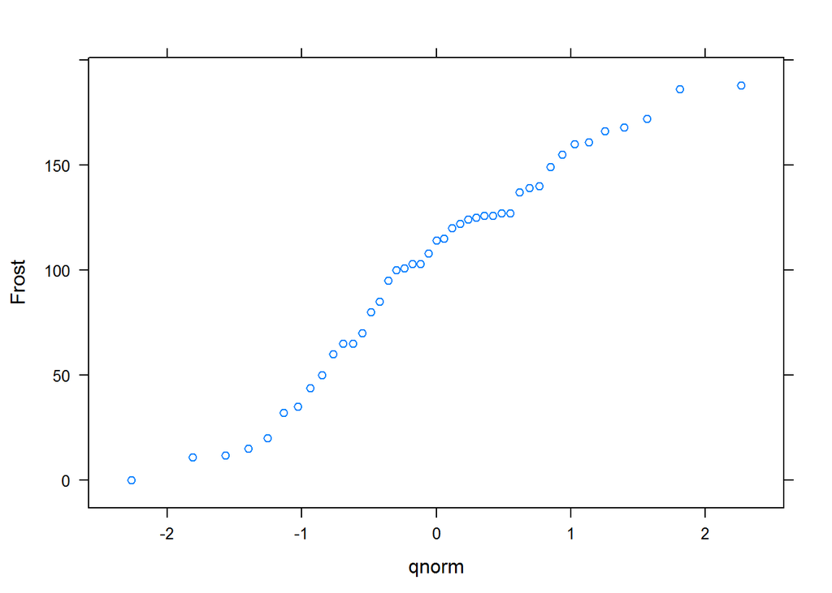

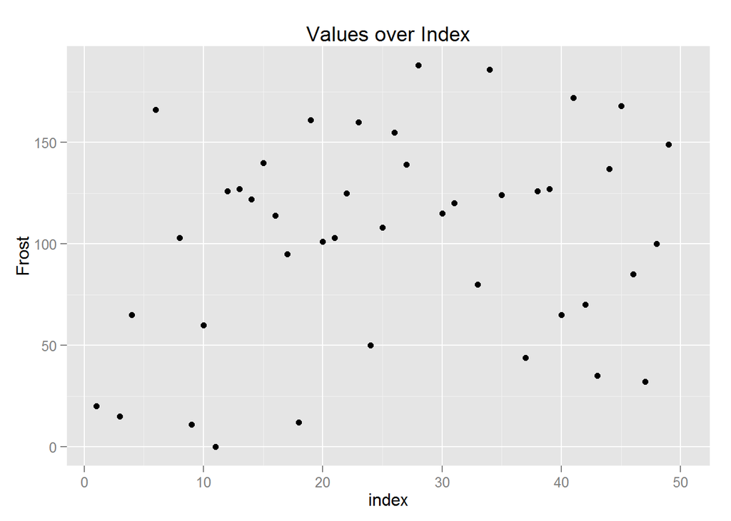

### Area

- **length**: *50*
- **naCnt**: *4*
- **naPerc**: *0.08*
- **unique_length**: *47*
- **uniquePerc**: *0.94*

|  | ct | prop |
| --- | --- | --- |
| **1049** | 1 | 0.02 |
| **1982** | 1 | 0.02 |
| **4862** | 1 | 0.02 |
| **6425** | 1 | 0.02 |
| **7521** | 1 | 0.02 |
| **7826** | 1 | 0.02 |
| **9267** | 1 | 0.02 |
| **9891** | 1 | 0.02 |
| **24070** | 1 | 0.02 |
| **30225** | 1 | 0.02 |

- **fivenum**:

  | min | low-hindge | median | up-hindge | max |
  | --- | --- | --- | --- | --- |
  | 1049 | 36097 | 55106 | 81787 | 566432 |

- **keystats**:

  | mean | sd | skewness | kurtosis |
  | --- | --- | --- | --- |
  | 72593 | 88201 | 3.979 | 18.92 |

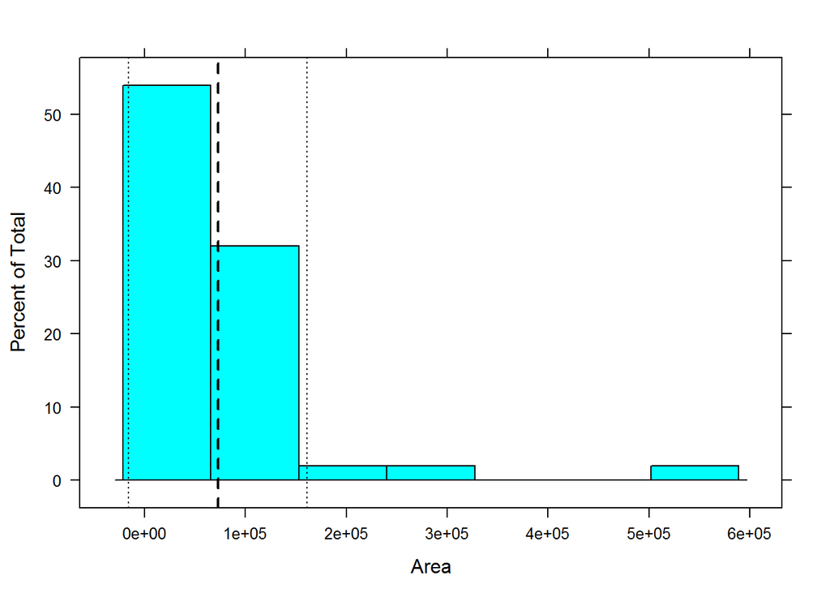

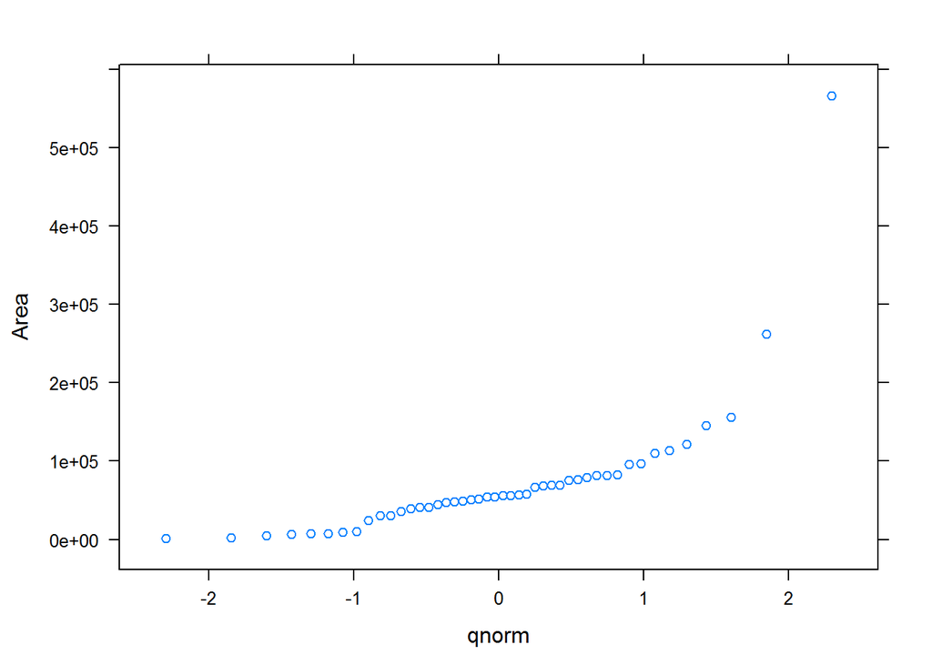

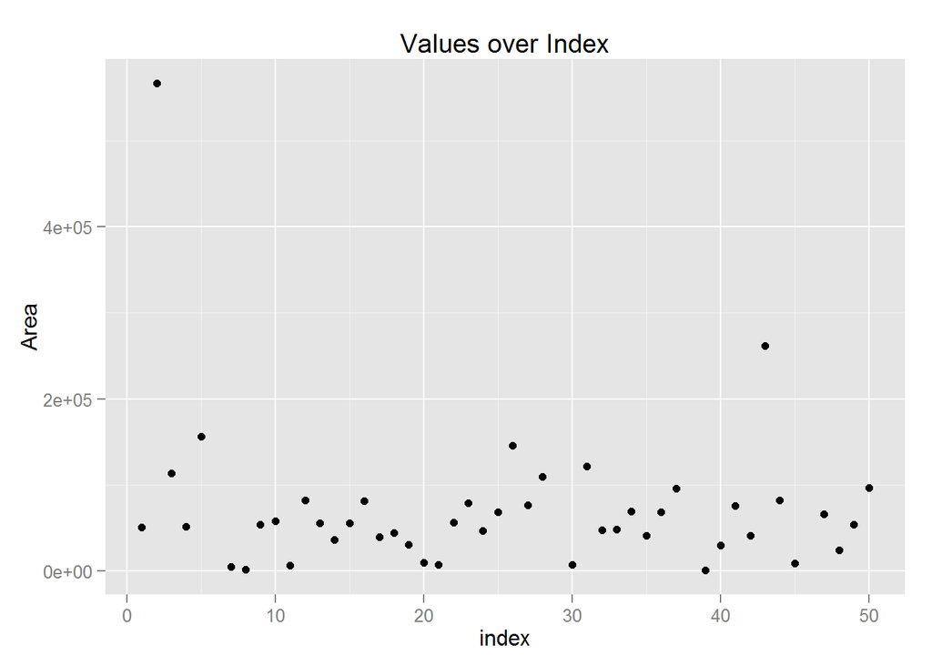

### rand_dates

- **length**: *50*
- **naCnt**: *2*
- **naPerc**: *0.04*
- **unique_length**: *49*
- **uniquePerc**: *0.98*

|  | ct | prop |
| --- | --- | --- |
| **2000-02-22** | 1 | 0.02 |
| **2000-08-16** | 1 | 0.02 |
| **2000-09-14** | 1 | 0.02 |
| **2001-10-22** | 1 | 0.02 |
| **2002-06-25** | 1 | 0.02 |
| **2002-10-14** | 1 | 0.02 |
| **2002-12-06** | 1 | 0.02 |
| **2003-02-08** | 1 | 0.02 |
| **2003-05-30** | 1 | 0.02 |
| **2003-08-20** | 1 | 0.02 |

- **keystats**:

  | mean | median | min | max |
  | --- | --- | --- | --- |
  | 2007-07-30 | 2007-10-04 | 2000-02-22 | 2015-12-25 |

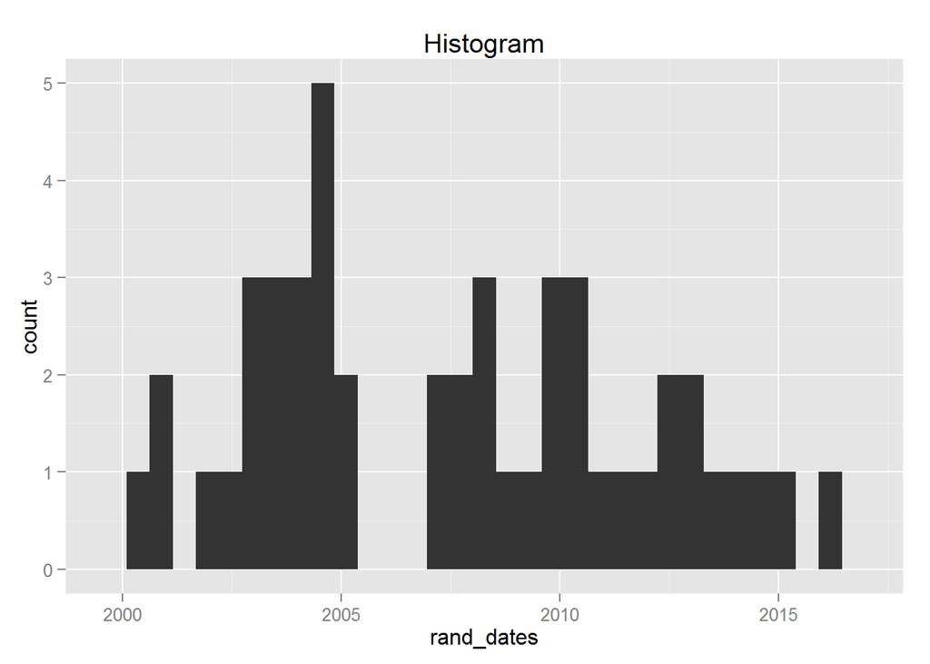

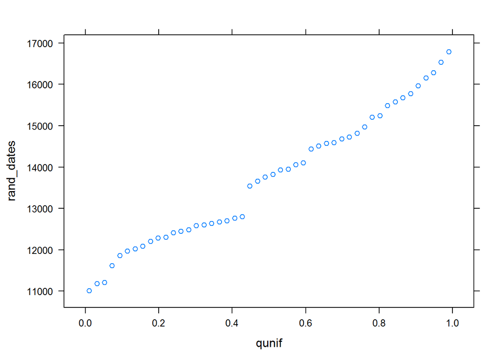

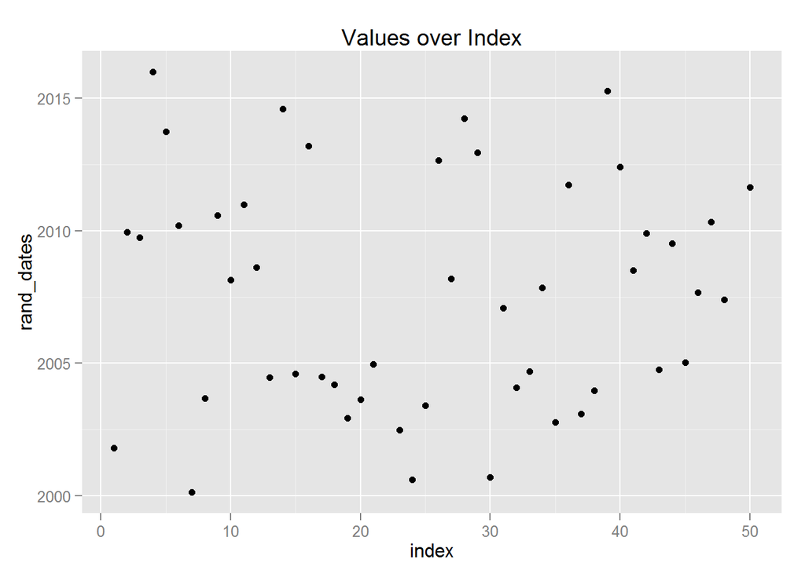

### rand_bool

- **length**: *50*
- **naCnt**: *5*
- **naPerc**: *0.1*
- **unique_length**: *3*
- **uniquePerc**: *0.06*

|  | ct | prop |
| --- | --- | --- |
| **TRUE** | 26 | 0.52 |
| **FALSE** | 19 | 0.38 |

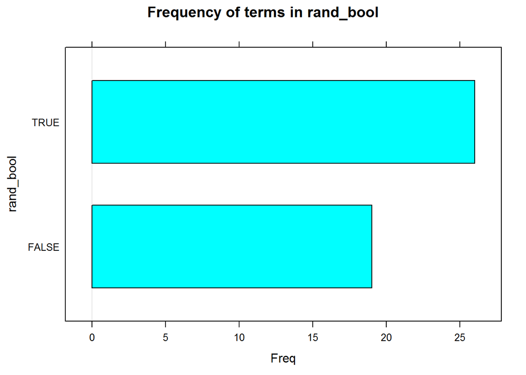

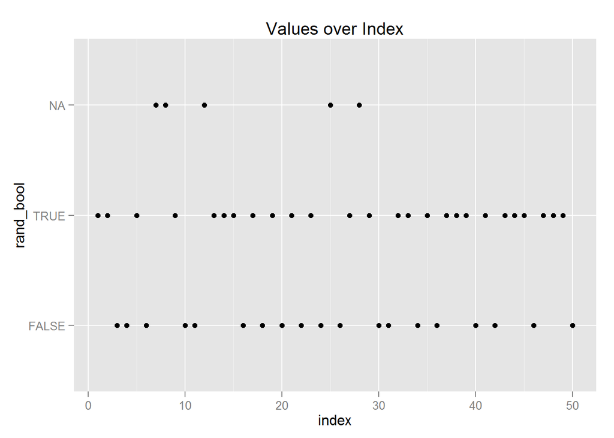